# Mental Health & Predictable Work Schedules

Schedule Volatility, Front-loading, and Household Wellbeing

Jingyao

二月 24, 2026

```r
data_path <- "C:/Users/jingy/Dropbox/VIP/09. Main study/09. Data/20. Generated/simon_analysis/30_merged_panel-hh_id-period.dta"
if (!file.exists(data_path)) stop("Error: Data file not found at: ", data_path)
data <- read_dta(data_path)
cat("Loaded:", nrow(data), "rows x", ncol(data), "columns\n")
```

```r
data_analysis <- data %>%
    mutate(
        group_label = case_when(
            control == 1 ~ "Control",
            predictable == 1 & period == 0 ~ "Baseline",
            predictable == 1 & high_draw == 1 ~ "High Draw",
            predictable == 1 & high_draw == 0 ~ "Low Draw",
            TRUE ~ "Unknown"
        ),
        period_label = case_when(
            period == 0 ~ "Period 0 (Baseline)",
            TRUE ~ paste0("Period ", period)
        )
    )
```

```r
schedule_chars <- data %>%
    filter(predictable == 1, period > 0) %>%
    arrange(hh_id, period) %>%
    group_by(schedule) %>%
    summarise(
        prop_high = mean(high_draw, na.rm = TRUE),
        n_switches = mean(
            tapply(high_draw, hh_id, function(x) sum(abs(diff(x)), na.rm = TRUE)),
            na.rm = TRUE
        ),
        front_loading = mean(
            tapply(seq_along(high_draw), hh_id, function(idx) {
                hd <- high_draw[idx]
                w <- rev(seq_along(hd))
                weighted.mean(hd, w = w, na.rm = TRUE)
            }),
            na.rm = TRUE
        ),
        .groups = "drop"
    ) %>%
    mutate(
        volatility_cat = case_when(
            n_switches <= 1 ~ "Low Volatility (<=1 switch)",
            n_switches <= 3 ~ "Medium Volatility (2-3 switches)",
            TRUE ~ "High Volatility (>=4 switches)"
        ),
        timing_cat = case_when(
            front_loading > 0.55 ~ "Front-loaded (High draws early)",
            front_loading < 0.45 ~ "Back-loaded (High draws late)",
            TRUE ~ "Balanced timing"
        ),
        vol_fl = n_switches * front_loading,
        vol_fl_grp = cut(vol_fl,
            breaks = quantile(vol_fl, probs = c(0, 1 / 3, 2 / 3, 1), na.rm = TRUE),
            labels = c("Low composite", "Medium composite", "High composite"),
            include.lowest = TRUE
        )
    )

data_analysis <- data_analysis %>%
    left_join(
        schedule_chars %>%
            select(schedule, volatility_cat, timing_cat,
                   n_switches, front_loading, vol_fl, vol_fl_grp),
        by = "schedule"
    )
```

# 1 Introduction

This document investigates whether the **shape** of an assigned income schedule — not just total income — causally affects mental health and household wellbeing in the VIP predictable-schedule study.

Each household in the predictable arm is randomly assigned to one of **20 income schedules**. Every schedule spans 6 periods and contains exactly **3 High (H) and 3 Low (L)** draw periods, so total income is equalized across all households by design. What varies is the *ordering* of draws. Because assignment is random, any systematic differences in outcomes across schedules must be caused by the schedule shape itself.

The document is organised as follows: Section 2 defines the three schedule-shape measures, presents the **main decomposition regression**, and shows how each component’s effect evolves across the 6 periods. Section 3 presents the **ICC analysis** — a complementary way to quantify how much outcome variance schedules explain.

# 2 Key Measures and Main Result

## 2.1 Definitions

We characterise each schedule using three constructed variables. These are computed once per schedule (averaging over all households assigned to it) and then merged into the household-period panel.

**`n_switches` — Income Volatility**

The number of H↔︎L transitions in the 6-period draw sequence. This ranges from **1** (HHHLLL: one H→L switch at the midpoint) to **5** (HLHLHL: income alternates every single period). A higher value means a more volatile income path — households face frequent reversals between high and low income states. This is the measure most intuitively associated with “instability.”

> **Why it matters for mental health:** Frequent reversals may cause repeated cycles of raised and dashed expectations. Even if households know their schedule in advance, adapting behaviour to a highly volatile sequence is cognitively and practically demanding.

**`front_loading` — Income Timing**

A position-weighted mean of the draw sequence, assigning higher weight to earlier periods:

$$\text{front_loading} =
\frac{\sum_{t=1}^{6}(7-t)\cdot \mathbf{1}[\text{draw}_t =
H]}{\sum_{t=1}^{6}(7-t)} = \frac{6 \cdot d_1 + 5 \cdot d_2 + 4 \cdot d_3
+ 3 \cdot d_4 + 2 \cdot d_5 + 1 \cdot d_6}{21}$$

where $d_t = 1$ if period $t$ is a High draw and 0 otherwise. Reference values:

| Schedule | Pattern | `front_loading` |
| --- | --- | --- |
| HHHLLL | H early | ≈ 0.71 |
| HLHLHL | Alternating | ≈ 0.57 |
| LLLHHH | H late | ≈ 0.29 |

A value close to 1 means H draws are concentrated early (front-loaded); close to 0 means H draws come late (back-loaded); 0.5 means balanced timing.

> **Why it matters:** A front-loaded household receives abundant income early but then endures a prolonged stretch of low income — potentially feeling like a deprivation relative to earlier periods. The opposite holds for back-loaded households, who might experience low income early as normal, then enjoy a later windfall.

**`vol_fl` — Composite Index**

$$\text{vol_fl} = n\_switches \times
front\_loading$$

This composite is large only when a schedule is *both* frequently alternating *and* front-loaded. The intuition: volatile switching is most psychologically disruptive when it begins from a position of early high income — the household experiences repeated downward reversals from an established high baseline. A highly volatile but back-loaded schedule partially cancels out, since income starts low and the volatility is less salient. For regression, `vol_fl` is standardised to mean 0, SD 1.

> **Summary:** `vol_fl` captures the “worst-case” schedule shape — many switches AND high draws concentrated early. It is our primary summary index, and the decomposition below separates the contribution of each component.

```r
# Data and label objects used throughout the document — output suppressed.
data_reg <- data_analysis %>%
    filter(predictable == 1, period > 0) %>%
    mutate(vol_fl_std = as.numeric(scale(vol_fl)))

reg_outcomes <- c(
    "phq2_z", "gad2_z",
    "total_income_99", "total_consumption_99", "food_consumption_total_99",
    "asset_net_99", "svg_savings_flow_99",
    "days_worked", "working_adults_corrected"
)

reg_labels <- c(
    phq2_z                    = "Depression (PHQ-2)",
    gad2_z                    = "Anxiety (GAD-2)",
    total_income_99           = "Total Income",
    total_consumption_99      = "Total Consumption",
    food_consumption_total_99 = "Food Consumption",
    asset_net_99              = "Net Assets",
    svg_savings_flow_99       = "Savings Flow",
    days_worked               = "Days Worked",
    working_adults_corrected  = "Working Adults"
)
```

## 2.2 Decomposition: Volatility vs Front-loading vs Current Draw

The composite `vol_fl` bundles two distinct schedule features. The table below separates their contributions using five specifications per outcome. **This is the main result of the document.**

| Column | Regressors | Question answered |
| --- | --- | --- |
| **(1) vol_fl** | composite only | Does the combined index predict outcomes? |
| **(2) switches** | `n_switches` only | Is volatility (frequency of switching) sufficient? |
| **(3) front_load** | `front_loading` only | Is timing (H draws early vs late) sufficient? |
| **(4) decomp** | both components | Which dominates when both are included simultaneously? |
| **(5) full** | both + `high_draw` | Does schedule shape survive controlling for whether the household is *currently* in a High draw period? |

Column (5) is a robustness check: `high_draw = 1` in periods when the household is currently receiving the High income draw. If the effect of `vol_fl` were purely mechanical — simply reflecting that High draw periods have higher income — it should disappear once we control for `high_draw`. Persistence in column (5) indicates genuine structural effects of schedule shape beyond the current-period draw.

```r
data_reg2 <- data_reg %>%
    mutate(
        sw_std = as.numeric(scale(n_switches)),
        fl_std = as.numeric(scale(front_loading))
    )

decomp_outcomes <- c(
    phq2_z                    = "Depression (PHQ-2)",
    gad2_z                    = "Anxiety (GAD-2)",
    total_income_99           = "Total Income",
    total_consumption_99      = "Total Consumption",
    loan_total_outstanding_99 = "Loan Outstanding",
    svg_savings_flow_99       = "Savings Flow",
    days_worked               = "Days Worked"
)

fit_decomp <- function(y, spec) {
    fml <- switch(spec,
        vfl    = as.formula(paste0(y, " ~ vol_fl_std               | period")),
        sw     = as.formula(paste0(y, " ~ sw_std                   | period")),
        fl     = as.formula(paste0(y, " ~ fl_std                   | period")),
        decomp = as.formula(paste0(y, " ~ sw_std + fl_std          | period")),
        full   = as.formula(paste0(y, " ~ sw_std + fl_std + high_draw | period"))
    )
    tryCatch(feols(fml, cluster = ~hh_id, data = data_reg2), error = function(e) NULL)
}

specs  <- c("vfl", "sw", "fl", "decomp", "full")
sp_sfx <- c("(1) vol_fl", "(2) switches", "(3) front_load", "(4) decomp", "(5) full")

build_decomp <- function(outcomes_named) {
    mods <- list()
    for (y in names(outcomes_named)) {
        nm <- outcomes_named[[y]]
        for (i in seq_along(specs)) {
            mods[[paste0(nm, " | ", sp_sfx[i])]] <- fit_decomp(y, specs[i])
        }
    }
    Filter(Negate(is.null), mods)
}

coef_decomp <- c(
    "vol_fl_std" = "vol_fl composite (std.)",
    "sw_std"     = "N switches / volatility (std.)",
    "fl_std"     = "Front-loading (std.)",
    "high_draw"  = "High draw (current period)"
)
notes_decomp <- paste0(
    "Predictable group, periods 1–6. Period FE. SEs clustered at HH. ",
    "sw_std = standardised n_switches; fl_std = standardised front_loading. ",
    "Column (5) adds current-period draw dummy as robustness check."
)

cat("### Panel A: Mental Health\n\n")
```

### 2.2.1 Panel A: Mental Health

```r
modelsummary(
    build_decomp(decomp_outcomes[c("phq2_z", "gad2_z")]),
    coef_map = coef_decomp, fmt = 3,
    stars    = c("*" = 0.1, "**" = 0.05, "***" = 0.01),
    gof_omit = "AIC|BIC|Log|RMSE|Std|R2 Adj|Within|Pseudo",
    title    = "Panel A — Mental Health: Decomposing Volatility vs Front-loading",
    notes    = notes_decomp, output = "html"
)
```

Panel A — Mental Health: Decomposing Volatility vs Front-loading

|  | Depression (PHQ-2) \| (1) vol_fl | Depression (PHQ-2) \| (2) switches | Depression (PHQ-2) \| (3) front_load | Depression (PHQ-2) \| (4) decomp | Depression (PHQ-2) \| (5) full | Anxiety (GAD-2) \| (1) vol_fl | Anxiety (GAD-2) \| (2) switches | Anxiety (GAD-2) \| (3) front_load | Anxiety (GAD-2) \| (4) decomp | Anxiety (GAD-2) \| (5) full |
| --- | --- | --- | --- | --- | --- | --- | --- | --- | --- | --- |
| vol_fl composite (std.) | 0.000 |  |  |  |  | 0.030 |  |  |  |  |
|  | (0.024) |  |  |  |  | (0.026) |  |  |  |  |
| N switches / volatility (std.) |  | 0.005 |  | 0.005 | 0.005 |  | 0.012 |  | 0.012 | 0.012 |
|  |  | (0.024) |  | (0.024) | (0.024) |  | (0.026) |  | (0.026) | (0.026) |
| Front-loading (std.) |  |  | -0.015 | -0.015 | -0.015 |  |  | 0.035 | 0.035 | 0.035 |
|  |  |  | (0.025) | (0.025) | (0.025) |  |  | (0.027) | (0.028) | (0.028) |
| High draw (current period) |  |  |  |  | -0.011 |  |  |  |  | -0.051 |
|  |  |  |  |  | (0.039) |  |  |  |  | (0.039) |
| Num.Obs. | 2239 | 2239 | 2239 | 2239 | 2239 | 2239 | 2239 | 2239 | 2239 | 2239 |
| R2 | 0.030 | 0.030 | 0.031 | 0.031 | 0.031 | 0.049 | 0.048 | 0.049 | 0.049 | 0.050 |
| FE: period | X | X | X | X | X | X | X | X | X | X |

* p < 0.1, ** p < 0.05, *** p < 0.01  
Predictable group, periods 1–6. Period FE. SEs clustered at HH. sw_std = standardised n_switches; fl_std = standardised front_loading. Column (5) adds current-period draw dummy as robustness check.

```r
cat("\n\n")
```

```r
cat("### Panel B: Economic Outcomes\n\n")
```

### 2.2.2 Panel B: Economic Outcomes

```r
modelsummary(
    build_decomp(decomp_outcomes[c("total_income_99", "total_consumption_99",
                                   "loan_total_outstanding_99", "svg_savings_flow_99")]),
    coef_map = coef_decomp, fmt = "%.0f",
    stars    = c("*" = 0.1, "**" = 0.05, "***" = 0.01),
    gof_omit = "AIC|BIC|Log|RMSE|Std|R2 Adj|Within|Pseudo",
    title    = "Panel B — Economic Outcomes: Decomposing Volatility vs Front-loading",
    notes    = notes_decomp, output = "html"
)
```

Panel B — Economic Outcomes: Decomposing Volatility vs Front-loading

|  | Total Income \| (1) vol_fl | Total Income \| (2) switches | Total Income \| (3) front_load | Total Income \| (4) decomp | Total Income \| (5) full | Total Consumption \| (1) vol_fl | Total Consumption \| (2) switches | Total Consumption \| (3) front_load | Total Consumption \| (4) decomp | Total Consumption \| (5) full | Loan Outstanding \| (1) vol_fl | Loan Outstanding \| (2) switches | Loan Outstanding \| (3) front_load | Loan Outstanding \| (4) decomp | Loan Outstanding \| (5) full | Savings Flow \| (1) vol_fl | Savings Flow \| (2) switches | Savings Flow \| (3) front_load | Savings Flow \| (4) decomp | Savings Flow \| (5) full |
| --- | --- | --- | --- | --- | --- | --- | --- | --- | --- | --- | --- | --- | --- | --- | --- | --- | --- | --- | --- | --- |
| vol_fl composite (std.) | 28** |  |  |  |  | -6 |  |  |  |  | -15 |  |  |  |  | -8 |  |  |  |  |
|  | (12) |  |  |  |  | (18) |  |  |  |  | (12) |  |  |  |  | (6) |  |  |  |  |
| N switches / volatility (std.) |  | 27** |  | 27** | 27** |  | -13 |  | -12 | -12 |  | -16 |  | -16 | -16 |  | -7 |  | -7 | -7 |
|  |  | (12) |  | (12) | (12) |  | (20) |  | (20) | (20) |  | (14) |  | (14) | (14) |  | (6) |  | (6) | (6) |
| Front-loading (std.) |  |  | 12 | 13 | 13 |  |  | 24 | 24 | 24 |  |  | -5 | -6 | -6 |  |  | -6 | -6 | -6 |
|  |  |  | (13) | (13) | (13) |  |  | (18) | (18) | (18) |  |  | (12) | (12) | (12) |  |  | (5) | (5) | (5) |
| High draw (current period) |  |  |  |  | 6 |  |  |  |  | -11 |  |  |  |  | -26 |  |  |  |  | 23 |
|  |  |  |  |  | (18) |  |  |  |  | (20) |  |  |  |  | (19) |  |  |  |  | (22) |
| Num.Obs. | 2246 | 2246 | 2246 | 2246 | 2246 | 2246 | 2246 | 2246 | 2246 | 2246 | 2246 | 2246 | 2246 | 2246 | 2246 | 2092 | 2092 | 2092 | 2092 | 2092 |
| R2 | 0.025 | 0.025 | 0.022 | 0.026 | 0.026 | 0.110 | 0.111 | 0.112 | 0.113 | 0.113 | 0.034 | 0.034 | 0.033 | 0.034 | 0.035 | 0.002 | 0.002 | 0.002 | 0.002 | 0.003 |
| FE: period | X | X | X | X | X | X | X | X | X | X | X | X | X | X | X | X | X | X | X | X |

* p < 0.1, ** p < 0.05, *** p < 0.01  
Predictable group, periods 1–6. Period FE. SEs clustered at HH. sw_std = standardised n_switches; fl_std = standardised front_loading. Column (5) adds current-period draw dummy as robustness check.

```r
cat("\n\n")
```

```r
cat("### Panel C: Labor\n\n")
```

### 2.2.3 Panel C: Labor

```r
modelsummary(
    build_decomp(decomp_outcomes["days_worked"]),
    coef_map = coef_decomp, fmt = 2,
    stars    = c("*" = 0.1, "**" = 0.05, "***" = 0.01),
    gof_omit = "AIC|BIC|Log|RMSE|Std|R2 Adj|Within|Pseudo",
    title    = "Panel C — Labor: Decomposing Volatility vs Front-loading",
    notes    = notes_decomp, output = "html"
)
```

Panel C — Labor: Decomposing Volatility vs Front-loading

|  | Days Worked \| (1) vol_fl | Days Worked \| (2) switches | Days Worked \| (3) front_load | Days Worked \| (4) decomp | Days Worked \| (5) full |
| --- | --- | --- | --- | --- | --- |
| vol_fl composite (std.) | -0.07 |  |  |  |  |
|  | (0.13) |  |  |  |  |
| N switches / volatility (std.) |  | -0.12 |  | -0.12 | -0.12 |
|  |  | (0.12) |  | (0.12) | (0.12) |
| Front-loading (std.) |  |  | -0.04 | -0.05 | -0.04 |
|  |  |  | (0.14) | (0.14) | (0.14) |
| High draw (current period) |  |  |  |  | 0.36* |
|  |  |  |  |  | (0.22) |
| Num.Obs. | 2246 | 2246 | 2246 | 2246 | 2246 |
| R2 | 0.039 | 0.039 | 0.039 | 0.039 | 0.041 |
| FE: period | X | X | X | X | X |

* p < 0.1, ** p < 0.05, *** p < 0.01  
Predictable group, periods 1–6. Period FE. SEs clustered at HH. sw_std = standardised n_switches; fl_std = standardised front_loading. Column (5) adds current-period draw dummy as robustness check.

## 2.3 Dynamic Effects: How Each Component’s Impact Evolves by Period

The regression tables above pool all 6 periods together. This section asks: **does the effect of each predictor grow, fade, or reverse over time?** For each period (1–6), we run a cross-sectional OLS regression with one predictor at a time — the composite (`vol_fl`), volatility (`n_switches`), or front-loading — and plot the resulting coefficients with 95% CIs. Comparing the three lines reveals which component drives effects early vs late in the study.

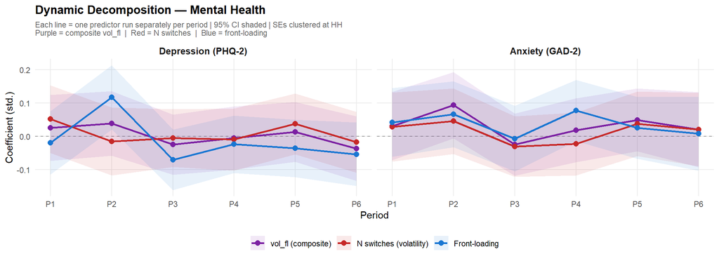

```r
plot_predictors <- c("vol_fl_std", "sw_std", "fl_std")
pred_labels     <- c(
    vol_fl_std = "vol_fl (composite)",
    sw_std     = "N switches (volatility)",
    fl_std     = "Front-loading"
)
pred_colors <- c(
    "vol_fl (composite)"      = "#7B1FA2",
    "N switches (volatility)" = "#C62828",
    "Front-loading"           = "#1976D2"
)

# For each outcome × period × predictor, fit a separate cross-sectional regression
dyn_decomp <- lapply(names(decomp_outcomes), function(outcome) {
    lapply(1:6, function(p) {
        sub <- data_reg2 %>% filter(period == p)
        if (!outcome %in% names(sub) || nrow(sub) < 10) return(NULL)
        lapply(plot_predictors, function(pred) {
            fml <- as.formula(paste0(outcome, " ~ ", pred))
            m   <- tryCatch(feols(fml, cluster = ~hh_id, data = sub),
                            error = function(e) NULL)
            if (is.null(m)) return(NULL)
            b  <- coef(m)[pred]
            se <- sqrt(vcov(m)[pred, pred])
            data.frame(outcome = outcome, period = p, predictor = pred,
                       coef = b, se = se, stringsAsFactors = FALSE)
        }) %>% dplyr::bind_rows()
    }) %>% dplyr::bind_rows()
}) %>%
    dplyr::bind_rows() %>%
    mutate(
        OutcomeLabel = factor(decomp_outcomes[outcome], levels = decomp_outcomes),
        PredLabel    = factor(pred_labels[predictor],
                              levels = pred_labels[plot_predictors]),
        lo95 = coef - 1.96 * se,
        hi95 = coef + 1.96 * se
    )

plot_decomp_dyn <- function(outcome_keys, title_str, ncols = 2, h = 4) {
    df <- dyn_decomp %>%
        filter(outcome %in% outcome_keys) %>%
        mutate(OutcomeLabel = droplevels(OutcomeLabel))
    ggplot(df, aes(x = period, y = coef,
                   color = PredLabel, fill = PredLabel)) +
        geom_hline(yintercept = 0, linetype = "dashed",
                   color = "gray60", linewidth = 0.4) +
        geom_ribbon(aes(ymin = lo95, ymax = hi95),
                    alpha = 0.10, color = NA) +
        geom_line(linewidth = 0.9) +
        geom_point(size = 2.5) +
        scale_x_continuous(breaks = 1:6, labels = paste0("P", 1:6)) +
        scale_color_manual(values = pred_colors, name = NULL) +
        scale_fill_manual(values  = pred_colors, name = NULL) +
        facet_wrap(~OutcomeLabel, scales = "fixed", ncol = ncols) +
        labs(
            title    = title_str,
            subtitle = paste0(
                "Each line = one predictor run separately per period | ",
                "95% CI shaded | SEs clustered at HH\n",
                "Purple = composite vol_fl  |  Red = N switches  |  Blue = front-loading"
            ),
            x = "Period", y = "Coefficient (std.)"
        ) +
        theme_minimal(base_size = 11) +
        theme(
            strip.text       = element_text(face = "bold", size = 10),
            panel.grid.minor = element_blank(),
            legend.position  = "bottom",
            plot.title       = element_text(face = "bold"),
            plot.subtitle    = element_text(size = 8.5, color = "gray40")
        )
}

plot_decomp_dyn(c("phq2_z", "gad2_z"),
                "Dynamic Decomposition — Mental Health", ncols = 2)
```

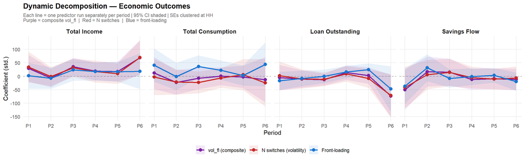

```r
plot_decomp_dyn(
    c("total_income_99", "total_consumption_99",
      "loan_total_outstanding_99", "svg_savings_flow_99"),
    "Dynamic Decomposition — Economic Outcomes", ncols = 4
)
```

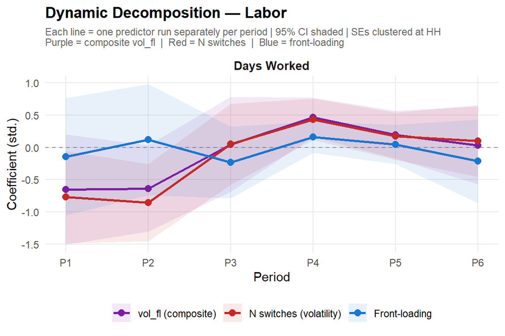

```r
plot_decomp_dyn("days_worked", "Dynamic Decomposition — Labor", ncols = 1)
```

# 3 ICC Analysis: How Much Variance Do Schedules Explain?

## 3.1 What the ICC Measures

The **Intra-Class Correlation (ICC)** answers: *of all the variation in an outcome across households and time periods, what fraction is explained by which schedule group the household was assigned to?*

We fit a **null mixed model** for each outcome and grouping dimension — a model with only a random intercept for the group, no other predictors:

$$\text{outcome}_{it} = \mu +
\alpha_{g(i)} + \varepsilon_{it}$$

where $\alpha_{g(i)} \sim N(0, \sigma^2_{\text{between}})$ is a random effect for schedule group $g$ and $\varepsilon_{it} \sim N(0, \sigma^2_{\text{within}})$ is the residual. The ICC is then:

$$\text{ICC} =
\frac{\sigma^2_{\text{between}}}{\sigma^2_{\text{between}} +
\sigma^2_{\text{within}}}$$

**Plain English:** ICC is the share of *total* variance attributable to group membership.

- ICC = **2%** → 2% of total variation in the outcome is explained by schedule assignment; the remaining 98% is within-schedule variation (household-to-household differences unrelated to which schedule they received).
- ICC = **50%** → equal split between between-schedule and within-schedule variance.
- ICC = **99%** → nearly all variation is between schedule groups; households on the same schedule behave almost identically.

> **Question:** “Does 1% mean the ratio of variance within a schedule is 1% of across schedules?” — **No.** The ICC is the ratio of *between*-group variance to *total* variance, not within to between. A 1% ICC means $\sigma^2_{\text{between}}$ is 1% of total, and $\sigma^2_{\text{within}}$ is 99% of total — i.e., within-schedule variance is about 99 times *larger* than between-schedule variance, meaning schedules explain very little. (If within were 1% of across, that would correspond to an ICC near 99%, not 1%.)

## 3.2 How It Is Computed

The ICC is extracted using `icc()` from the **`performance`** package (part of the `easystats` suite), which is the standard R function for this purpose. It fits the null mixed model via `lmer()` from `lme4` and returns `ICC_adjusted = σ²_between / (σ²_between + σ²_within)`. There is no need for a custom function — this is a well-tested, standard computation.

## 3.3 How to Read the Table

**Rows** are outcomes grouped by domain. The single ICC column groups households by their assigned schedule (20 groups), treating each distinct schedule as a separate group. The ICC value tells you what share of total outcome variance is explained by which of the 20 schedules a household received.

**A note on NA cells:** An NA cell means the ICC could not be estimated for that outcome. This happens when the mixed model (`lmer`) fails to fit — most commonly because the outcome variable has too many missing values, or there is near-zero residual variation. NA is not a substantive result; it simply means there was insufficient information to calculate the ICC for that outcome.

```r
icc_data <- data_analysis %>% filter(predictable == 1, period > 0)

icc_outcomes <- c(
    "phq2_z", "gad2_z",
    "total_income_99", "total_consumption_99", "food_consumption_total_99",
    "asset_net_99", "svg_savings_flow_99",
    "days_worked", "working_adults_corrected"
)

outcome_labels <- c(
    phq2_z                    = "Depression (PHQ-2)",
    gad2_z                    = "Anxiety (GAD-2)",
    total_income_99           = "Total Income",
    total_consumption_99      = "Total Consumption",
    food_consumption_total_99 = "Food Consumption",
    asset_net_99              = "Net Asset Accumulation",
    svg_savings_flow_99       = "Savings Flow",
    days_worked               = "Days Worked",
    working_adults_corrected  = "Working Adults"
)

# Uses performance::icc() — the standard package function.
# For a null mixed model lmer(y ~ 1 + (1|group)), icc()$ICC_adjusted equals
# var_between / (var_between + var_within), which is the standard ICC1.
#
# NAs arise from "singular" lmer fits: when between-group variance is estimated
# as exactly 0, performance::icc() returns NA rather than 0. A singular fit
# simply means no detectable between-group variance, i.e. ICC = 0%, so we
# replace those NAs with 0. Singularity warnings are suppressed accordingly.
calc_icc <- function(outcome, group_var, data) {
    if (!outcome %in% names(data) || !group_var %in% names(data)) return(NA_real_)
    sub <- data[!is.na(data[[outcome]]) & !is.na(data[[group_var]]), ]
    if (nrow(sub) < 10 || sd(sub[[outcome]], na.rm = TRUE) == 0) return(NA_real_)
    tryCatch({
        m <- suppressWarnings(
            lmer(as.formula(paste0(outcome, " ~ 1 + (1 | ", group_var, ")")),
                 data = sub, REML = TRUE)
        )
        icc_val <- suppressMessages(performance::icc(m)$ICC_adjusted)
        # Singular fit → var_between = 0 → ICC = 0, not NA
        if (is.na(icc_val)) 0 else icc_val
    }, error = function(e) NA_real_)
}

icc_table <- data.frame(Outcome = icc_outcomes, stringsAsFactors = FALSE) %>%
    rowwise() %>%
    mutate(ICC = calc_icc(Outcome, "schedule", icc_data)) %>%
    ungroup() %>%
    mutate(
        OutcomeLabel = outcome_labels[Outcome],
        Category     = case_when(
            Outcome %in% c("phq2_z", "gad2_z")                       ~ "Mental Health",
            Outcome %in% c("days_worked", "working_adults_corrected") ~ "Labor",
            TRUE                                                       ~ "Financial"
        )
    ) %>%
    arrange(Category, Outcome) %>%
    select(Category, OutcomeLabel, ICC)

icc_table %>%
    gt() %>%
    tab_header(
        title    = "ICC by Outcome: Variance Explained by Schedule Assignment",
        subtitle = "ICC = share of total outcome variance attributable to which of the 20 schedules a household received"
    ) %>%
    fmt_percent(columns = ICC, decimals = 1) %>%
    cols_label(Category = "Domain", OutcomeLabel = "Outcome", ICC = "ICC (20 schedules)") %>%
    tab_style(style = cell_text(weight = "bold"), locations = cells_column_labels()) %>%
    tab_options(table.width = pct(60)) %>%
    print()
```

ICC by Outcome: Variance Explained by Schedule Assignment

ICC = share of total outcome variance attributable to which of the 20 schedules a household received

| Domain | Outcome | ICC (20 schedules) |
| --- | --- | --- |
| Financial | Net Asset Accumulation | 0.1% |
| Financial | Food Consumption | 1.6% |
| Financial | Savings Flow | NA |
| Financial | Total Consumption | 1.6% |
| Financial | Total Income | 0.8% |
| Labor | Days Worked | 0.9% |
| Labor | Working Adults | 0.2% |
| Mental Health | Anxiety (GAD-2) | 0.3% |
| Mental Health | Depression (PHQ-2) | 0.2% |

```r
cat("\n**Example reading:** If Depression shows 2%, it means 2% of all variation in PHQ-2 scores is explained by which of the 20 schedules a household received. The remaining 98% is within-schedule variation — household-to-household differences unrelated to schedule assignment.\n\n")
```

**Example reading:** If Depression shows 2%, it means 2% of all variation in PHQ-2 scores is explained by which of the 20 schedules a household received. The remaining 98% is within-schedule variation — household-to-household differences unrelated to schedule assignment.